# DS4B-short-report-2

Tsz Ching Li u7630977

22-9-2023

Welcome to the first tutorial of BIOL3207 course.

Here are the learning outcome of this tutorial:

1. Understand the purpose of EDA
2. Basic Data Exploratory
3. Sanity Check
4. Choose a Right Visualization
5. Create Visualization

# What is EDA?

Exploratory Data Analysis (EDA) is an approach to study a data by summarizing data statistic and visualise them. We can have better understanding to the patterns of observations in the data. We may even discover interesting relationships within data when we are doing the exploratory!

Today we are going to use the frog species dataset which is obtained by citizens with the FrogID apps in Australia to learn some EDA techniques. The data is huge and maybe messy, so it is going to be fun to have a look at it and see what we could find!

Here we load the libraries that are usually used in EDA

```r
library(tidyverse)
```

```r
# tidyverse actually include dplyr and ggplot2
library(dplyr)
library(ggplot2)
library(skimr)
```

# Load data

```r
data <- read_csv("raw_data/FrogID4_final_dataset.csv")
```

# Basic Exploratory

Usually the first thing we do after receiving a data, we will have an overview of the each column and data in it.

The **str()** function allow us to have a look with all the type of observations

```r
str(data)
```

```
## spc_tbl_ [484,227 × 21] (S3: spec_tbl_df/tbl_df/tbl/data.frame)
##  $ datasetName                  : chr [1:484227] "FrogID" "FrogID" "FrogID" "FrogID" ...
##  $ basisOfRecord                : chr [1:484227] "Occurrence" "Occurrence" "Occurrence" "Occurrence" ...
##  $ dataGeneralizations          : chr [1:484227] "Georeference rounded to 0.1 degrees" "Georeference rounded to 0.1 degrees" "Georeference rounded to 0.1 degrees" "Georeference rounded to 0.1 degrees" ...
##  $ occurrenceID                 : num [1:484227] 1 2 3 4 5 6 7 8 9 10 ...
##  $ sex                          : chr [1:484227] "male" "male" "male" "male" ...
##  $ lifestage                    : chr [1:484227] "adult" "adult" "adult" "adult" ...
##  $ behavior                     : chr [1:484227] "calling" "calling" "calling" "calling" ...
##  $ samplingProtocol             : chr [1:484227] "call recording" "call recording" "call recording" "call recording" ...
##  $ country                      : chr [1:484227] "Australia" "Australia" "Australia" "Australia" ...
##  $ machineObservation           : chr [1:484227] "An occurrence record based on an audio recording" "An occurrence record based on an audio recording" "An occurrence record based on an audio recording" "An occurrence record based on an audio recording" ...
##  $ eventID                      : num [1:484227] 4493 4496 4503 5349 5603 ...
##  $ decimalLatitude              : num [1:484227] -38.1 -17 -17 -38.1 -38.1 -41.3 -41.3 -17 -16.5 -26.7 ...
##  $ decimalLongitude             : num [1:484227] 145 146 146 145 145 ...
##  $ scientificName               : chr [1:484227] "Limnodynastes peronii" "Litoria rheocola" "Litoria dayi" "Limnodynastes peronii" ...
##  $ eventDate                    : Date[1:484227], format: "2017-11-14" "2017-11-14" ...
##  $ eventTime                    : chr [1:484227] "22:49:20+1100" "22:18:49+1000" "22:43:09+1000" "08:45:45+1100" ...
##  $ coordinateUncertaintyInMeters: num [1:484227] 10000 10000 10000 10000 10000 10000 10000 10000 10000 10000 ...
##  $ geoprivacy                   : chr [1:484227] "obscured" "obscured" "obscured" "obscured" ...
##  $ recordedBy                   : num [1:484227] 3817 1595 1595 4558 3817 ...
##  $ stateProvince                : chr [1:484227] "VIC" "QLD" "QLD" "VIC" ...
##  $ modified                     : Date[1:484227], format: "2023-05-29" "2023-05-29" ...
##  - attr(*, "spec")=
##   .. cols(
##   ..   datasetName = col_character(),
##   ..   basisOfRecord = col_character(),
##   ..   dataGeneralizations = col_character(),
##   ..   occurrenceID = col_double(),
##   ..   sex = col_character(),
##   ..   lifestage = col_character(),
##   ..   behavior = col_character(),
##   ..   samplingProtocol = col_character(),
##   ..   country = col_character(),
##   ..   machineObservation = col_character(),
##   ..   eventID = col_double(),
##   ..   decimalLatitude = col_double(),
##   ..   decimalLongitude = col_double(),
##   ..   scientificName = col_character(),
##   ..   eventDate = col_date(format = ""),
##   ..   eventTime = col_character(),
##   ..   coordinateUncertaintyInMeters = col_double(),
##   ..   geoprivacy = col_character(),
##   ..   recordedBy = col_double(),
##   ..   stateProvince = col_character(),
##   ..   modified = col_date(format = "")
##   .. )
##  - attr(*, "problems")=<externalptr>
```

With **summary()**, we can know the length and class of observation we have, if it is numeric, its minimum, median, mean, etc will also be shown, so we can quickly know what we are dealing with.

```r
summary(data)
```

```
##  datasetName        basisOfRecord      dataGeneralizations  occurrenceID
##  Length:484227      Length:484227      Length:484227       Min.   :     1
##  Class :character   Class :character   Class :character    1st Qu.:121058
##  Mode  :character   Mode  :character   Mode  :character    Median :242114
##                                                            Mean   :242114
##                                                            3rd Qu.:363170
##                                                            Max.   :484227
##      sex             lifestage           behavior         samplingProtocol
##  Length:484227      Length:484227      Length:484227      Length:484227
##  Class :character   Class :character   Class :character   Class :character
##  Mode  :character   Mode  :character   Mode  :character   Mode  :character
##
##
##
##    country          machineObservation    eventID       decimalLatitude
##  Length:484227      Length:484227      Min.   :  2831   Min.   :-43.609
##  Class :character   Class :character   1st Qu.: 85600   1st Qu.:-35.180
##  Mode  :character   Mode  :character   Median :160881   Median :-33.325
##                                        Mean   :159581   Mean   :-31.170
##                                        3rd Qu.:229180   3rd Qu.:-28.798
##                                        Max.   :556831   Max.   : -9.416
##  decimalLongitude scientificName       eventDate           eventTime
##  Min.   :113.5    Length:484227      Min.   :2017-11-10   Length:484227
##  1st Qu.:145.1    Class :character   1st Qu.:2019-10-15   Class :character
##  Median :149.8    Mode  :character   Median :2020-10-10   Mode  :character
##  Mean   :145.4                       Mean   :2020-06-14
##  3rd Qu.:151.4                       3rd Qu.:2021-03-22
##  Max.   :153.6                       Max.   :2021-11-09
##  coordinateUncertaintyInMeters  geoprivacy          recordedBy
##  Min.   :-2147480.0            Length:484227      Min.   :    19
##  1st Qu.:       5.0            Class :character   1st Qu.:  7906
##  Median :      10.0            Mode  :character   Median : 15985
##  Mean   :     550.9                               Mean   : 53948
##  3rd Qu.:      48.0                               3rd Qu.: 28616
##  Max.   : 1445600.0                               Max.   :836365
##  stateProvince         modified
##  Length:484227      Min.   :2023-05-29
##  Class :character   1st Qu.:2023-05-29
##  Mode  :character   Median :2023-05-29
##                     Mean   :2023-05-29
##                     3rd Qu.:2023-05-29
##                     Max.   :2023-05-29
```

Or we can also use **head()** to have a look with the first 6 rows of the data set.

```r
head(data)
```

```
## # A tibble: 6 × 21
##   datasetName basisOfRecord dataGeneralizations     occurrenceID sex   lifestage
##   <chr>       <chr>         <chr>                          <dbl> <chr> <chr>
## 1 FrogID      Occurrence    Georeference rounded t…            1 male  adult
## 2 FrogID      Occurrence    Georeference rounded t…            2 male  adult
## 3 FrogID      Occurrence    Georeference rounded t…            3 male  adult
## 4 FrogID      Occurrence    Georeference rounded t…            4 male  adult
## 5 FrogID      Occurrence    Georeference rounded t…            5 male  adult
## 6 FrogID      Occurrence    Georeference rounded t…            6 male  adult
## # ℹ 15 more variables: behavior <chr>, samplingProtocol <chr>, country <chr>,
## #   machineObservation <chr>, eventID <dbl>, decimalLatitude <dbl>,
## #   decimalLongitude <dbl>, scientificName <chr>, eventDate <date>,
## #   eventTime <chr>, coordinateUncertaintyInMeters <dbl>, geoprivacy <chr>,
## #   recordedBy <dbl>, stateProvince <chr>, modified <date>
```

# Sanity Check

Since the data is big and is collected by citizens, the data will probably be messy and missing with “NA” which affect our analysis, so we have to check and handle these unwanted data.

This is to check is there any cell with “NA”.

```r
any(is.na(data))
```

```
## [1] FALSE
```

The output is “FALSE”, so there is no “NA”, that’s nice!

Now, we have to see is there any data doesn’t make sense

```r
# check is there any category not a type of sex
unique(data$sex)
```

```
## [1] "male"
```

```r
# check if all the is there any state not in Australia
unique(data$stateProvince)
```

```
## [1] "VIC"               "QLD"               "TAS"
## [4] "NSW"               "NT"                "SA"
## [7] "Other Territories" "WA"                "ACT"
```

```r
# check if the country is only Aus
unique(data$country)
```

```
## [1] "Australia"
```

# Visualisation

After we have check the data without any problem and have briefly understood what’s in the data, we can try to plot something out and see is there any interesting correlation!

## Frog Location

This data contain the location where frogs were found, we can use these data to try understanding the habitat of them.

We can try plotting which latitude and longitude have the most frogs discovered. Since latitude and longitude are continuous variable, so to find their frequency, it will great to use a histogram!

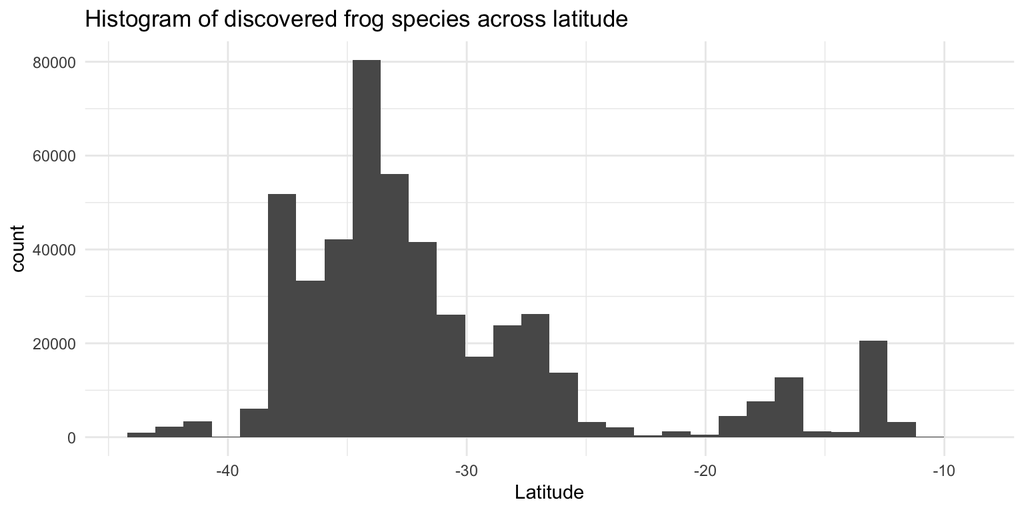

```r
ggplot(data, aes(decimalLatitude)) +
  geom_histogram() +
  labs(title = "Histogram of discovered frog species across latitude", x = "Latitude") +
  theme_minimal()
```

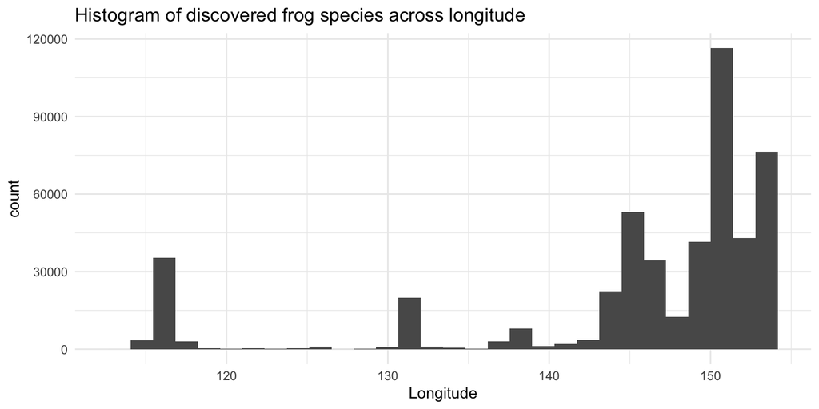

```r
ggplot(data, aes(decimalLongitude)) +
  geom_histogram() +
  labs(title = "Histogram of discovered frog species across longitude", x = "Longitude") +
  theme_minimal()
```

We can see that the histogram have shown higher distribution at -40 to -30 and above 140 for latitude and longitude respectively. Since they are coordinate, we can actually try plotting them out at the same time. For two continuous variables, scatter plot will absolutely be a good fit!

Now, we try to use **geom_point()** to see what happen.

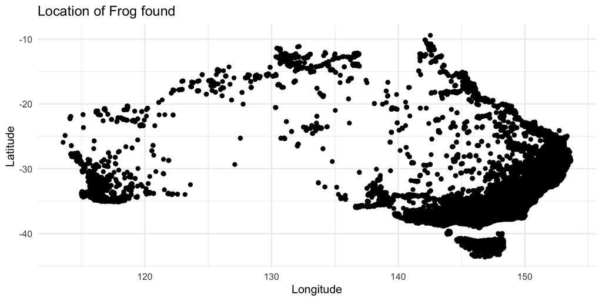

```r
ggplot(data, aes(x = decimalLongitude, y = decimalLatitude)) + # since Latitude is the horizontal line on earth and Longitude is the vertical line on earth, we will try to plot them on y and x respectively
  geom_point() +
  labs(title= "Location of Frog found", x = "Longitude", y = "Latitude") +
  theme_minimal()
```

It looks like a map of Australia, right? And we can actually see some grouping if we try using **color()** in **aes()**, so points can be grouped by color and act as another variable to observe!

Since it is related to location, we can try to use stateProvince for the coloring. Also, we can actually try to highlight what does other territories mean and see if we can group them in either of the state/ territories.

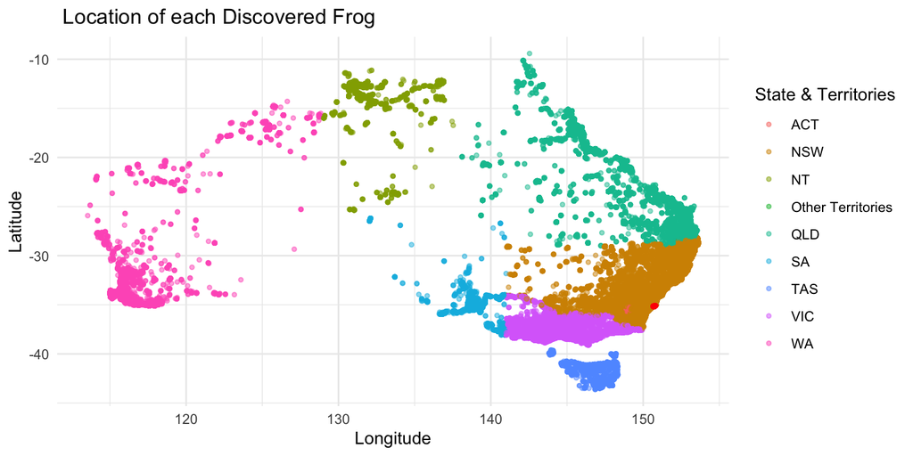

```r
OT <- data |>
  filter(stateProvince == "Other Territories")

ggplot() +
  geom_point(data = data,
             aes(x = decimalLongitude, y = decimalLatitude, color = stateProvince),
             size = 1,
             alpha = .5) +
  geom_point(data = OT, aes(x = decimalLongitude, y = decimalLatitude), color ="red", size = 1) +
  labs(x = "Longitude",
       y = "Latitude",
       color = "State & Territories",
       title =  " Location of each Discovered Frog") +
  theme_minimal()
```

Here we can see all the data is grouped by stateProvince and we have highlighted the other territories into red. Now, we know other territories is an error, they should be grouped as NSW, since all place in Australia should be under a state or territory.

We can modify the data of “Other Territories” to NSW.

```r
data$stateProvince[data$stateProvince == "Other Territories"] <- "NSW"

# or by dplyr package
data <- data |>
  mutate(stateProvince = ifelse(stateProvince == "Other Territories", "NSW", stateProvince))
```

Then go back to run again the scatter plot without highlighting the other territories, the color should now not include “Other Territories .

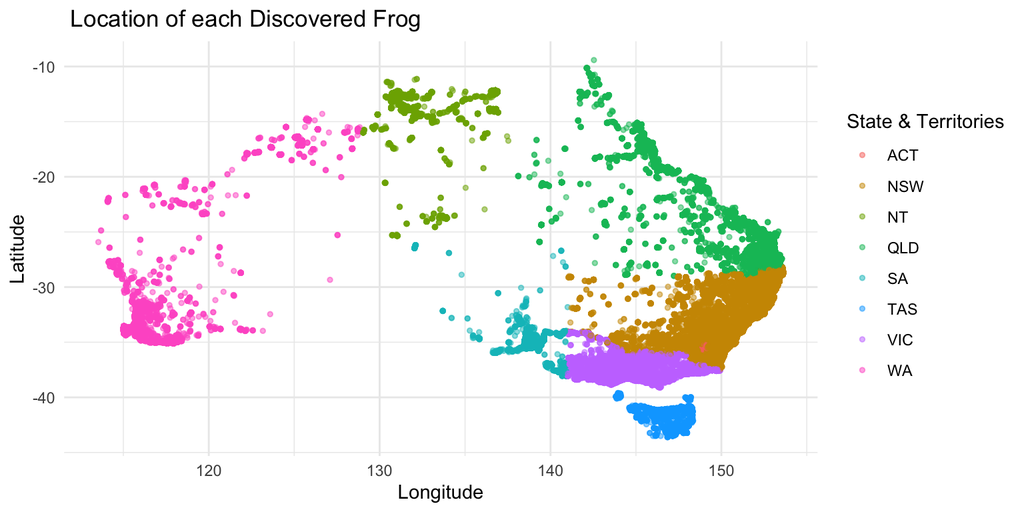

```r
ggplot() +
  geom_point(data = data,
             aes(x = decimalLongitude, y = decimalLatitude, color = stateProvince),
             size = 1,
             alpha = .5) +
  labs(x = "Longitude",
       y = "Latitude",
       color = "State & Territories",
       title =  " Location of each Discovered Frog") +
  theme_minimal()
```

## Time of Frog Discovery

We are trying to find what time do citizen usually discover a frog by state/ territories, so that we can see when do frogs usually be more active and being seen in each state/ territories.

By the **summary()**/ **str()** above, we know that the eventTime is actually a chraracter string, this is not convenient for us if we would like to find out the time when frog is more actively seen. Therefore, we try to turn it from character to a time string with **as.hms()**

```r
library (hms)
data$eventTime <- as.hms(data$eventTime)
```

After we have change it to a hour-min-sec string, we can now introduce another plotting, the violin plot! It allows us to plot a non continuous and a continuous value and see its distribution along the y axis.

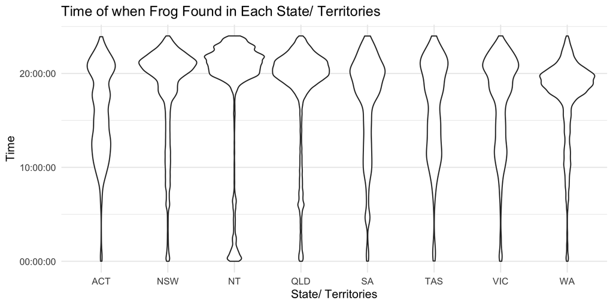

```r
ggplot(data, aes(x = stateProvince, y = eventTime)) +
  geom_violin() +
  labs(title = "Time of when Frog Found in Each State/ Territories", y = "Time", x = "State/ Territories") +
  theme_minimal()
```

Hope you all have learnt much and find it fun, for further plotting method of ggplot and tidy data function, you can search “ggplot cheatsheat” and “dplyr cheatsheet” online.